# Introduction & Linear Regression Analysis

Hugo Trivino

```r
setwd(".")
library(psych)
library(dplyr)
```

# 1 Recitation problems

## 1.1

### a) If the gender is predicted using machine learning algorithms it would be a data mining task. However, if it is only filtering data, it can be done using a simple DBMS which is not a data mining task.

### b) Again if the task is calculated using deterministic information is surely a database or software development task. However, if it is predicted by training a learning algorithms it can be done using datamining.

### c) Same answer as (a) and (b)

### d) No, it is a database task

### e) No, it is a simple probability task

### f) Yes, this is most likely implemented by using some data mining algorithm.

### g) Yes, since abnormalities can be detected by using clustering algorithms, it is likely a data mining task

### h) Yes, because the answer it is not straight forward and it has to be learned from sensors and previous experiences.

### i) Yes, it can be done using datamining to learn how to distinguish the signals that can be noise vs the desired sound.

## 1.3

### a) Since Census data is likely to be public it would not have important privacy implications.

### b) Yes, this information should be treated carefully to provide privacy to users of the website.

### c) Images from orbit satelites can be private in the case of spy satelites. However, in many cases this information is public

### d) This information is already public enough not to be important for privacy.

### e) Depending of the methods of gathering this information and the legislation of the country of residence.

## 2.2

### (a) Binary, qualitative, ordinal

### (b) Continuous, quantitative, ratio

### (c) Discrete, qualitative, ordinal

### (d) Discrete, quantitative, ratio

### (e) Discrete, qualitative, ordinal

### (f) Continuous, quantitative, ratio

### (g) Discrete, quantitative, ratio

### (h) Discrete, qualitative, nominal

### (i) Discrete, qualitative, ordinal

### (j) Discrete, qualitative, ordinal

### (k) Continuous, quantitative, ratio

### (l) Continuous, quantitative, ratio

### (m) Discrete, qualitative, nominal

## 3

### (a) His boss is probably right because the counts of complaints by themselves are not a measure of satisfaction if not normalized by the total number of purchased products. If the best selling product has more sales is more likely to handle a greater number of complaints because more users are using it, not because it is worst or they wouldn’t buy it in the first place.

### (b) It is likely to be a ratio attribute that would be calculated based on some ordinal inputs from the user.

## 7

### Daily temperature is more likely to have a strong temporal correlation since the temperature fluctuates within each season slowly. It will highly depend of the specific application. There are places in the world with rainy seasons in which the temporal correlation of rain in a day is highly predictive for the next days.

## 12

### (a) Noise is normally not interesting or desirable. Outliers might be of high interest for some data mining applications like finding malicious trafic or anomalies.

### (b) Yes, it can look like a noise and be in fact an outlier

### (c) No, most of the time noise is produced by errors in the medium and not in the data. Outliers are part of the data.

### (d) No, the outlier can be clearly detected

### (e) Yes, this can happen (example can be when two bits are flipped so parity still check and now it looks like an outlier)

# 2 Practicum problems

## Problem 2.1

### a) Printing first 6 records

```r
college.df <- read.csv("College.csv",sep=",",header=T,stringsAsFactors = F)
head(college.df,6)
```

|  | Name | Private | Apps | Accept | Enroll | Top10perc | Top25perc | F.Undergrad | P.Undergrad | Outstate | Room.Board | Books | Personal | PhD | Terminal | S.F.Ratio | perc.alumni | Expend | Grad.Rate |
| --- | --- | --- | --- | --- | --- | --- | --- | --- | --- | --- | --- | --- | --- | --- | --- | --- | --- | --- | --- |
| 1 | Abilene Christian University | Yes | 1660 | 1232 | 721 | 23 | 52 | 2885 | 537 | 7440 | 3300 | 450 | 2200 | 70 | 78 | 18.1 | 12 | 7041 | 60 |
| 2 | Adelphi University | Yes | 2186 | 1924 | 512 | 16 | 29 | 2683 | 1227 | 12280 | 6450 | 750 | 1500 | 29 | 30 | 12.2 | 16 | 10527 | 56 |
| 3 | Adrian College | Yes | 1428 | 1097 | 336 | 22 | 50 | 1036 | 99 | 11250 | 3750 | 400 | 1165 | 53 | 66 | 12.9 | 30 | 8735 | 54 |
| 4 | Agnes Scott College | Yes | 417 | 349 | 137 | 60 | 89 | 510 | 63 | 12960 | 5450 | 450 | 875 | 92 | 97 | 7.7 | 37 | 19016 | 59 |
| 5 | Alaska Pacific University | Yes | 193 | 146 | 55 | 16 | 44 | 249 | 869 | 7560 | 4120 | 800 | 1500 | 76 | 72 | 11.9 | 2 | 10922 | 15 |
| 6 | Albertson College | Yes | 587 | 479 | 158 | 38 | 62 | 678 | 41 | 13500 | 3335 | 500 | 675 | 67 | 73 | 9.4 | 11 | 9727 | 55 |

### b) Printing totals private vs public colleges

```r
numPrivPubl<-table(college.df$Private)
names(numPrivPubl) <- c("Public","Private")
print(numPrivPubl)
```

```
 Public Private
    212     565
```

### c) Historigrams of Phd holding faculty

As shown in the folloring graphs, public colleges have a higher mean of PhD faculty. There are almost no public universities with less of 45% PhD holding faculty. In the private sector, there are far more universities in which more faculty without a PhD are allowed to teach. However, a greater amount of private colleges have more than 90% of their faculty holding PhD’s than in public institutions. This results shows that there is a far greater variance in the private colleges in their faculty selection.

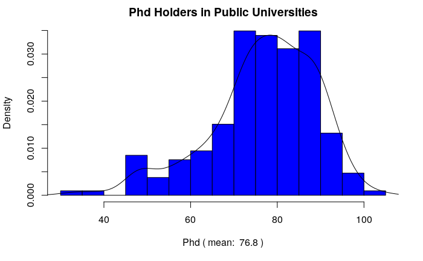

```r
public.df <- college.df[college.df$Private=="No",][-c(2)]
private.df <- college.df[college.df$Private=="Yes",][-c(2)]

hist(public.df$PhD,
     main="Phd Holders in Public Universities",
     xlab=paste("Phd ( mean:",sprintf("%5.1f",mean(public.df$PhD)),")"),
     col="blue",
     freq = FALSE,
     nclass = 20)
lines(density(public.df$PhD),col="black",type = "l")
```

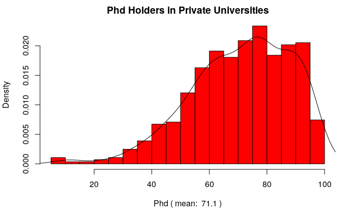

```r
hist(private.df$PhD,
     main="Phd Holders in Private Universities",
     xlab=paste("Phd ( mean:",sprintf("%5.1f",mean(private.df$PhD)),")"),
     freq=FALSE,
     col="red",
     nclass = 20
)
lines(density(private.df$PhD),col="black",type = "l")
```

### d) Printing colleges with lowest and highest graduation rates.

Colleges with the Lowest Graduation Rates

```r
collegeGrad.df <-college.df[college.df$Grad.Rate<=100,]
#There shouldn't be colleges with graduation rate higher than 100%
CollByGradRate.df <- select(arrange(collegeGrad.df,collegeGrad.df$Grad.Rate),Name,Grad.Rate)

 head(CollByGradRate.df,5)
```

|  | Name | Grad.Rate |
| --- | --- | --- |
| 1 | Texas Southern University | 10 |
| 2 | Alaska Pacific University | 15 |
| 3 | Montreat-Anderson College | 15 |
| 4 | Brewton-Parker College | 18 |
| 5 | Claflin College | 21 |

Colleges with the Highest Graduation Rates

```r
tail(CollByGradRate.df,5)
```

|  | Name | Grad.Rate |
| --- | --- | --- |
| 772 | Lindenwood College | 100 |
| 773 | Missouri Southern State College | 100 |
| 774 | Santa Clara University | 100 |
| 775 | Siena College | 100 |
| 776 | University of Richmond | 100 |

### e) Print summary, scatterplots, and personal insights on the data.

#### i)

```r
summary(college.df)
```

```
     Name             Private               Apps           Accept          Enroll       Top10perc
 Length:777         Length:777         Min.   :   81   Min.   :   72   Min.   :  35   Min.   : 1.00
 Class :character   Class :character   1st Qu.:  776   1st Qu.:  604   1st Qu.: 242   1st Qu.:15.00
 Mode  :character   Mode  :character   Median : 1558   Median : 1110   Median : 434   Median :23.00
                                       Mean   : 3002   Mean   : 2019   Mean   : 780   Mean   :27.56
                                       3rd Qu.: 3624   3rd Qu.: 2424   3rd Qu.: 902   3rd Qu.:35.00
                                       Max.   :48094   Max.   :26330   Max.   :6392   Max.   :96.00
   Top25perc      F.Undergrad     P.Undergrad         Outstate       Room.Board       Books
 Min.   :  9.0   Min.   :  139   Min.   :    1.0   Min.   : 2340   Min.   :1780   Min.   :  96.0
 1st Qu.: 41.0   1st Qu.:  992   1st Qu.:   95.0   1st Qu.: 7320   1st Qu.:3597   1st Qu.: 470.0
 Median : 54.0   Median : 1707   Median :  353.0   Median : 9990   Median :4200   Median : 500.0
 Mean   : 55.8   Mean   : 3700   Mean   :  855.3   Mean   :10441   Mean   :4358   Mean   : 549.4
 3rd Qu.: 69.0   3rd Qu.: 4005   3rd Qu.:  967.0   3rd Qu.:12925   3rd Qu.:5050   3rd Qu.: 600.0
 Max.   :100.0   Max.   :31643   Max.   :21836.0   Max.   :21700   Max.   :8124   Max.   :2340.0
    Personal         PhD            Terminal       S.F.Ratio      perc.alumni        Expend
 Min.   : 250   Min.   :  8.00   Min.   : 24.0   Min.   : 2.50   Min.   : 0.00   Min.   : 3186
 1st Qu.: 850   1st Qu.: 62.00   1st Qu.: 71.0   1st Qu.:11.50   1st Qu.:13.00   1st Qu.: 6751
 Median :1200   Median : 75.00   Median : 82.0   Median :13.60   Median :21.00   Median : 8377
 Mean   :1341   Mean   : 72.66   Mean   : 79.7   Mean   :14.09   Mean   :22.74   Mean   : 9660
 3rd Qu.:1700   3rd Qu.: 85.00   3rd Qu.: 92.0   3rd Qu.:16.50   3rd Qu.:31.00   3rd Qu.:10830
 Max.   :6800   Max.   :103.00   Max.   :100.0   Max.   :39.80   Max.   :64.00   Max.   :56233
   Grad.Rate
 Min.   : 10.00
 1st Qu.: 53.00
 Median : 65.00
 Mean   : 65.46
 3rd Qu.: 78.00
 Max.   :118.00
```

#### ii.

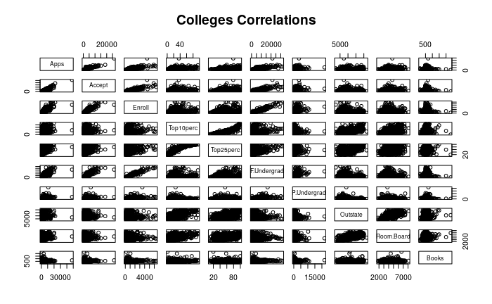

```r
#To look at a better resolution, uncomment
#bitmap("colleges.tiff", height = 4, width = 4, units = 'in', type="tifflzw", res=300)
pairs(college.df[,3:12],main="Colleges Correlations")
```

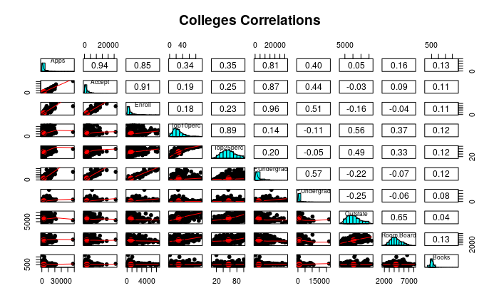

```r
pairs.panels(college.df[,3:12],
   main="Colleges Correlations",
   pch=19
   )
```

#### iii.

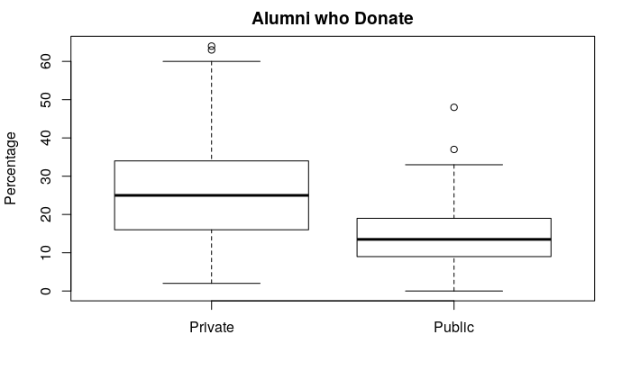

```r
names<-c("Private","Public")
boxplot(college.df[college.df$Private=="Yes",]$perc.alumni,college.df[college.df$Private=="No",]$perc.alumni,names=names,ylab="Percentage")
title("Alumni who Donate")
```

#### iv.

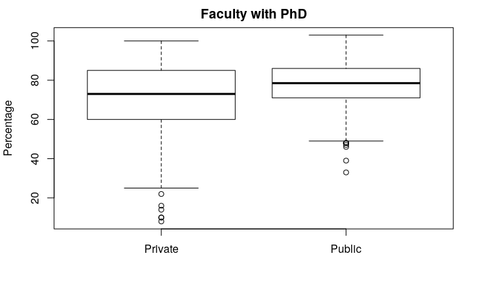

```r
names<-c("Private","Public")
boxplot(college.df[college.df$Private=="Yes",]$PhD,college.df[college.df$Private=="No",]$PhD,names=names,ylab="Percentage")
title("Faculty with PhD")
```

#### v.

```r
college<-college.df
Elite <- rep("No",nrow(college))
Elite[college$Top10perc > 50] <-"Yes"
Elite <- as.factor(Elite)
college <-data.frame(college,Elite)
summary(college)
```

```
     Name             Private               Apps           Accept          Enroll       Top10perc
 Length:777         Length:777         Min.   :   81   Min.   :   72   Min.   :  35   Min.   : 1.00
 Class :character   Class :character   1st Qu.:  776   1st Qu.:  604   1st Qu.: 242   1st Qu.:15.00
 Mode  :character   Mode  :character   Median : 1558   Median : 1110   Median : 434   Median :23.00
                                       Mean   : 3002   Mean   : 2019   Mean   : 780   Mean   :27.56
                                       3rd Qu.: 3624   3rd Qu.: 2424   3rd Qu.: 902   3rd Qu.:35.00
                                       Max.   :48094   Max.   :26330   Max.   :6392   Max.   :96.00
   Top25perc      F.Undergrad     P.Undergrad         Outstate       Room.Board       Books
 Min.   :  9.0   Min.   :  139   Min.   :    1.0   Min.   : 2340   Min.   :1780   Min.   :  96.0
 1st Qu.: 41.0   1st Qu.:  992   1st Qu.:   95.0   1st Qu.: 7320   1st Qu.:3597   1st Qu.: 470.0
 Median : 54.0   Median : 1707   Median :  353.0   Median : 9990   Median :4200   Median : 500.0
 Mean   : 55.8   Mean   : 3700   Mean   :  855.3   Mean   :10441   Mean   :4358   Mean   : 549.4
 3rd Qu.: 69.0   3rd Qu.: 4005   3rd Qu.:  967.0   3rd Qu.:12925   3rd Qu.:5050   3rd Qu.: 600.0
 Max.   :100.0   Max.   :31643   Max.   :21836.0   Max.   :21700   Max.   :8124   Max.   :2340.0
    Personal         PhD            Terminal       S.F.Ratio      perc.alumni        Expend
 Min.   : 250   Min.   :  8.00   Min.   : 24.0   Min.   : 2.50   Min.   : 0.00   Min.   : 3186
 1st Qu.: 850   1st Qu.: 62.00   1st Qu.: 71.0   1st Qu.:11.50   1st Qu.:13.00   1st Qu.: 6751
 Median :1200   Median : 75.00   Median : 82.0   Median :13.60   Median :21.00   Median : 8377
 Mean   :1341   Mean   : 72.66   Mean   : 79.7   Mean   :14.09   Mean   :22.74   Mean   : 9660
 3rd Qu.:1700   3rd Qu.: 85.00   3rd Qu.: 92.0   3rd Qu.:16.50   3rd Qu.:31.00   3rd Qu.:10830
 Max.   :6800   Max.   :103.00   Max.   :100.0   Max.   :39.80   Max.   :64.00   Max.   :56233
   Grad.Rate      Elite
 Min.   : 10.00   No :699
 1st Qu.: 53.00   Yes: 78
 Median : 65.00
 Mean   : 65.46
 3rd Qu.: 78.00
 Max.   :118.00
```

#### vi.

```r
par(mfrow=c(3,2))
hist(college[college$Elite=="Yes",]$PhD,
     main = "Elite Colleges",
     xlab=paste("Phd Faculty (mean:",
                sprintf("%5.1f",mean(college[college$Elite=="Yes",]$PhD))
                        ,")"),
     col="green")
hist(college[college$Elite=="No",]$PhD,
     main = "Non-Elite Colleges",
     xlab=paste("Phd Faculty (mean:",
                sprintf("%5.1f",mean(college[college$Elite=="No",]$PhD))
                        ,")"),
     col="red")
```

```r
hist(college[college$Elite=="Yes",]$Grad.Rate,
     main = "Elite Colleges",
     xlab=paste("Graduation Rate (mean:",
                sprintf("%5.1f",mean(college[college$Elite=="Yes",]$Grad.Rate))
                        ,")"),
     col="green")
hist(college[college$Elite=="No",]$Grad.Rate,
     main = "Non-Elite Colleges",
     xlab=paste("Graduation Rate (mean:",
                sprintf("%5.1f",mean(college[college$Elite=="No",]$Grad.Rate))
                        ,")"),
     col="red")
```

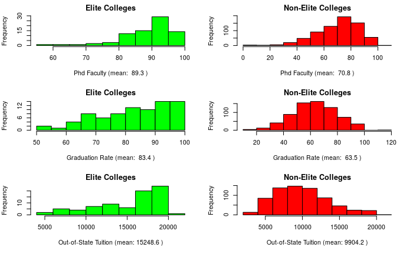

```r
hist(college[college$Elite=="Yes",]$Outstate,
     main = "Elite Colleges",
     xlab=paste("Out-of-State Tuition (mean:",
                sprintf("%5.1f",mean(college[college$Elite=="Yes",]$Outstate))
                        ,")"),
     col="green")
hist(college[college$Elite=="No",]$Outstate,
     main = "Non-Elite Colleges",
     xlab=paste("Out-of-State Tuition (mean:",
                sprintf("%5.1f",mean(college[college$Elite=="No",]$Outstate))
                        ,")"),
     col="red")
```

#### vii.

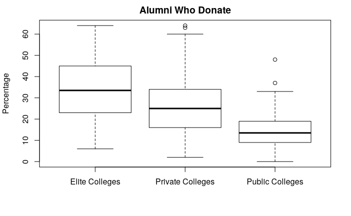

```r
names<-c("Elite Colleges","Private Colleges","Public Colleges")
boxplot(college[college$Elite=="Yes",]$perc.alumni,
        college.df[college.df$Private=="Yes",]$perc.alumni,
        college.df[college.df$Private=="No",]$perc.alumni,
        names=names,ylab="Percentage", main="Alumni Who Donate")
```

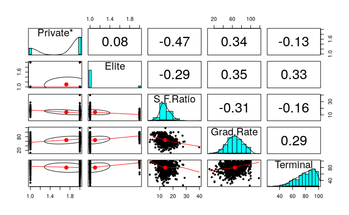

```r
pairs.panels(college[,c(2,20,16,19,15)])
```

## 2.2 Linear regression

### (a) Cleaning datasheet

#### i.

```r
mpg.df <- read.csv("auto-mpg.csv",sep=",",header=T,stringsAsFactors = F)
mpg.df <- mpg.df[-c(which(mpg.df$horsepower== "?")),]
```

#### ii.

```r
str(mpg.df$horsepower)
```

```
 chr [1:392] "130" "165" "150" "150" "140" "198" "220" "215" "225" "190" "170" "160" "150" "225" "95" ...
```

```r
mpg.df$horsepower <- as.integer(mpg.df$horsepower)
str(mpg.df$horsepower)
```

```
 int [1:392] 130 165 150 150 140 198 220 215 225 190 ...
```

### (b) Selecting the strongest correlation

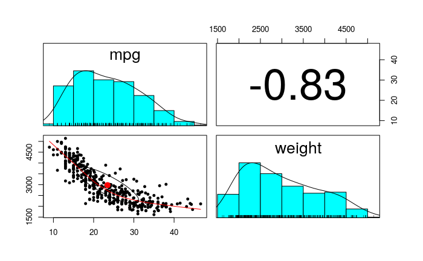

```r
typ <-c("double","integer","numeric")
x<-0
y<-0
listCorr=c()
namesOfCorr= c()
listAbs=c()
colNumber=c()
for (variable in mpg.df) {
  x=x+1
  name <-names(mpg.df)[x]
  if(typeof(variable)%in% typ){
    y=y+1
    plotting.df <-data.frame(mpg.df$mpg, variable)
    namesOfCorr[y] <-name
    listCorr[y]<-cor(plotting.df)[2]
    listAbs[y]<-abs(cor(plotting.df)[2])
    colNumber[y]<-x
  }
}
corr.df=data.frame(listCorr, listAbs,namesOfCorr,colNumber)
colnames(corr.df) <- c("correlation","absValue","field","columnNumber")
corr.df <-corr.df[-c(1),]
corr.df <- arrange(corr.df,corr.df$absValue)

pairs.panels(mpg.df[,c(1,tail(corr.df,1)$columnNumber)])
```

```r
model.mpg <- lm(formula = paste("mpg ~ ",tail(corr.df,1)$field,sep = "") ,data = mpg.df)
summary(model.mpg)
```

```
Call:
lm(formula = paste("mpg ~ ", tail(corr.df, 1)$field, sep = ""),
    data = mpg.df)

Residuals:
     Min       1Q   Median       3Q      Max
-11.9736  -2.7556  -0.3358   2.1379  16.5194

Coefficients:
             Estimate Std. Error t value Pr(>|t|)
(Intercept) 46.216524   0.798673   57.87   <2e-16 ***
weight      -0.007647   0.000258  -29.64   <2e-16 ***
---
Signif. codes:  0 ‘***’ 0.001 ‘**’ 0.01 ‘*’ 0.05 ‘.’ 0.1 ‘ ’ 1

Residual standard error: 4.333 on 390 degrees of freedom
Multiple R-squared:  0.6926,    Adjusted R-squared:  0.6918
F-statistic: 878.8 on 1 and 390 DF,  p-value: < 2.2e-16
```

### (c) Ploting regression line

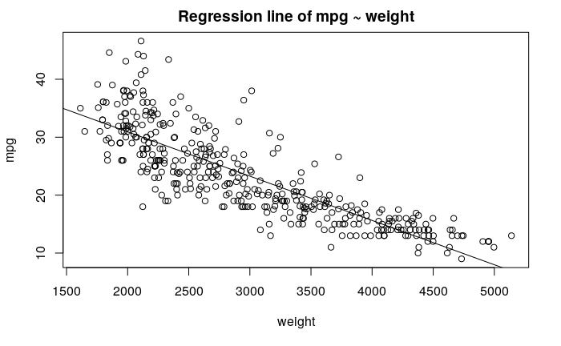

```r
plot(mpg.df[,c(tail(corr.df,1)$columnNumber,1)],main="Regression line of mpg ~ weight")
abline(model.mpg)
```

```r
set.seed(1122)
index <- sample(1:nrow(mpg.df), 0.80*dim(mpg.df)[1])
train.df <- mpg.df[index, ]
test.df <- mpg.df[-index, ]
```

### (d) Training model based on dataset

```r
train.model <- lm(formula = paste("mpg ~ ",paste(corr.df$field,collapse = " + ")) ,data = train.df)
summary(train.model)
```

```
Call:
lm(formula = paste("mpg ~ ", paste(corr.df$field, collapse = " + ")),
    data = train.df)

Residuals:
    Min      1Q  Median      3Q     Max
-9.4910 -1.9425 -0.0945  1.7932 13.3295

Coefficients:
               Estimate Std. Error t value Pr(>|t|)
(Intercept)  -1.851e+01  5.132e+00  -3.608 0.000361 ***
acceleration  1.385e-01  1.140e-01   1.215 0.225449
origin        1.487e+00  3.118e-01   4.769 2.87e-06 ***
model.year    7.484e-01  5.626e-02  13.304  < 2e-16 ***
cylinders    -5.343e-01  3.492e-01  -1.530 0.127066
horsepower   -1.399e-03  1.544e-02  -0.091 0.927843
displacement  2.087e-02  8.514e-03   2.452 0.014774 *
weight       -6.916e-03  8.055e-04  -8.586 4.69e-16 ***
---
Signif. codes:  0 ‘***’ 0.001 ‘**’ 0.01 ‘*’ 0.05 ‘.’ 0.1 ‘ ’ 1

Residual standard error: 3.289 on 305 degrees of freedom
Multiple R-squared:  0.8097,    Adjusted R-squared:  0.8053
F-statistic: 185.3 on 7 and 305 DF,  p-value: < 2.2e-16
```

#### i.

Since car.name is unique for each instance, it cannot be used as a predictor. #### ii.

```r
train.model <- lm(formula = paste("mpg ~ ",paste(corr.df$field,collapse = " + ")) ,data = train.df)
summary(train.model)
```

```
Call:
lm(formula = paste("mpg ~ ", paste(corr.df$field, collapse = " + ")),
    data = train.df)

Residuals:
    Min      1Q  Median      3Q     Max
-9.4910 -1.9425 -0.0945  1.7932 13.3295

Coefficients:
               Estimate Std. Error t value Pr(>|t|)
(Intercept)  -1.851e+01  5.132e+00  -3.608 0.000361 ***
acceleration  1.385e-01  1.140e-01   1.215 0.225449
origin        1.487e+00  3.118e-01   4.769 2.87e-06 ***
model.year    7.484e-01  5.626e-02  13.304  < 2e-16 ***
cylinders    -5.343e-01  3.492e-01  -1.530 0.127066
horsepower   -1.399e-03  1.544e-02  -0.091 0.927843
displacement  2.087e-02  8.514e-03   2.452 0.014774 *
weight       -6.916e-03  8.055e-04  -8.586 4.69e-16 ***
---
Signif. codes:  0 ‘***’ 0.001 ‘**’ 0.01 ‘*’ 0.05 ‘.’ 0.1 ‘ ’ 1

Residual standard error: 3.289 on 305 degrees of freedom
Multiple R-squared:  0.8097,    Adjusted R-squared:  0.8053
F-statistic: 185.3 on 7 and 305 DF,  p-value: < 2.2e-16
```

### (e) Selecting only three strong predictors

#### i. These three predictors were determined to be significant in the previous code

```r
train.model <- lm(formula =mpg ~ origin + model.year + weight ,data = train.df)
summary(train.model)
```

```
Call:
lm(formula = mpg ~ origin + model.year + weight, data = train.df)

Residuals:
    Min      1Q  Median      3Q     Max
-9.8280 -2.0987 -0.0985  1.7552 13.5701

Coefficients:
              Estimate Std. Error t value Pr(>|t|)
(Intercept) -1.679e+01  4.357e+00  -3.853 0.000142 ***
origin       1.232e+00  2.890e-01   4.262 2.69e-05 ***
model.year   7.314e-01  5.284e-02  13.841  < 2e-16 ***
weight      -5.870e-03  2.856e-04 -20.555  < 2e-16 ***
---
Signif. codes:  0 ‘***’ 0.001 ‘**’ 0.01 ‘*’ 0.05 ‘.’ 0.1 ‘ ’ 1

Residual standard error: 3.304 on 309 degrees of freedom
Multiple R-squared:  0.8055,    Adjusted R-squared:  0.8036
F-statistic: 426.5 on 3 and 309 DF,  p-value: < 2.2e-16
```

#### ii. Show the summary of the new model

```r
summary(train.model)
```

```
Call:
lm(formula = mpg ~ origin + model.year + weight, data = train.df)

Residuals:
    Min      1Q  Median      3Q     Max
-9.8280 -2.0987 -0.0985  1.7552 13.5701

Coefficients:
              Estimate Std. Error t value Pr(>|t|)
(Intercept) -1.679e+01  4.357e+00  -3.853 0.000142 ***
origin       1.232e+00  2.890e-01   4.262 2.69e-05 ***
model.year   7.314e-01  5.284e-02  13.841  < 2e-16 ***
weight      -5.870e-03  2.856e-04 -20.555  < 2e-16 ***
---
Signif. codes:  0 ‘***’ 0.001 ‘**’ 0.01 ‘*’ 0.05 ‘.’ 0.1 ‘ ’ 1

Residual standard error: 3.304 on 309 degrees of freedom
Multiple R-squared:  0.8055,    Adjusted R-squared:  0.8036
F-statistic: 426.5 on 3 and 309 DF,  p-value: < 2.2e-16
```

```r
anova(train.model)
```

```
Analysis of Variance Table

Response: mpg
            Df Sum Sq Mean Sq F value    Pr(>F)
origin       1 5586.4  5586.4  511.80 < 2.2e-16 ***
model.year   1 3766.9  3766.9  345.10 < 2.2e-16 ***
weight       1 4611.9  4611.9  422.52 < 2.2e-16 ***
Residuals  309 3372.8    10.9
---
Signif. codes:  0 ‘***’ 0.001 ‘**’ 0.01 ‘*’ 0.05 ‘.’ 0.1 ‘ ’ 1
```

### (f) Ploting the residuals shows that they are randomly cluster around zero

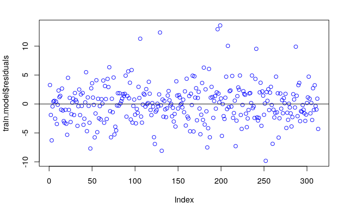

```r
plot(train.model$residuals,col="blue")
abline(0,0)
```

### (g) We can see that the data is homosceadastic slightly skewed. But it looks almost as gaussian curve.

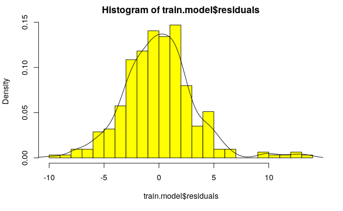

```r
hist(train.model$residuals, freq = FALSE,col="yellow", nclass=20)
lines(density(train.model$residuals))
```

### (h) Finding exact matchs

```r
dfs<- data.frame(test.df$mpg,round(predict(train.model, newdata=test.df),0))
differ <- dfs[,1]-dfs[,2]
colnames<-c("difference")
z=0
for (variable in differ) {
  if(variable == 0.0){
    z=z+1
  }
}

print(paste('If the model prediction is rounded to an integer value, the predictor would match successfully ',z," observations"))
```

```
[1] "If the model prediction is rounded to an integer value, the predictor would match successfully  7  observations"
```

```r
dfs<- data.frame(test.df$mpg,round(predict(train.model, newdata=test.df),1))
differ <- dfs[,1]-dfs[,2]
colnames<-c("difference")
z=0
for (variable in differ) {
  if(variable == 0.0){
    z=z+1
  }
}

print(paste('If the model prediction is rounded to one significant value, the predictor would match successfully ',z," observations"))
```

```
[1] "If the model prediction is rounded to one significant value, the predictor would match successfully  1  observations"
```

```r
#which(mpg.df$horsepower== "?")
#lines(dfs[,1])
#lines(dfs[,2])
```

#### i. Printing the error based statistics only using the residual vector.

```r
dfs<- data.frame(test.df$mpg,round(predict(train.model, newdata=test.df),0))
differ <- dfs[,1]-dfs[,2]
colnames<-c("difference")
z=0
RSS<-0
ESS<-0
for (x in 1:length(dfs[,1])){
  ESS=ESS + (dfs[x,1]-mean(dfs[,2]))^2
}
for (errs in differ) {
    RSS=RSS+errs^2
    #ESS=ESS+(errs-mean(differ))
}
RMSE=sqrt(mean((dfs[,1] -dfs[,2])^2))
RSE=sqrt((RSS)/(length(differ)-2))
TSS=ESS + RSS
print(paste("RSS: ",RSS))
```

```
[1] "RSS:  1002.61"
```

```r
print(paste("TSS: ",TSS))
```

```
[1] "TSS:  7467.01746835443"
```

```r
print(paste("RSE: ",RSE))
```

```
[1] "RSE:  3.60844967969751"
```

```r
print(paste("RMSE: ",RMSE))
```

```
[1] "RMSE:  3.56248029086265"
```